# South Florida Regulation Schedule

Point of Contact: Paul Julian (Paul.Julian@FloridaDEP.gov) and Alyssa Gilhooly (Alyssa.Gilhooly@FloridaDEP.gov)

Updated 2020-12-04 11:11:32

This webpage is intended to inform Agency representatives on stage elevation in the various waterbodies within the Everglades Region (North and South).

*Please note this analysis is using preliminary data and subject to change.*

### *Kissimmee Chain-of-Lakes*

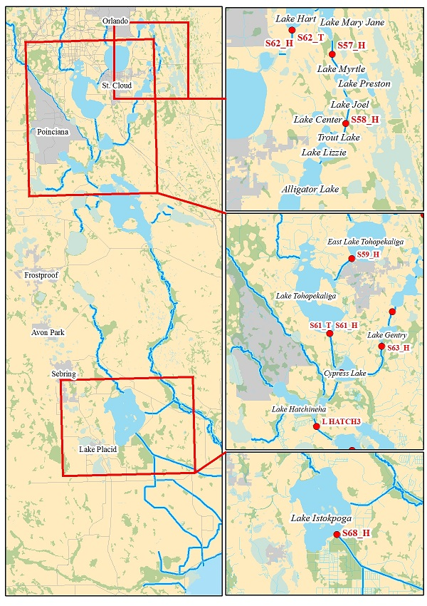

Kissimmee Chain-of-Lakes with structures and lakes identified.

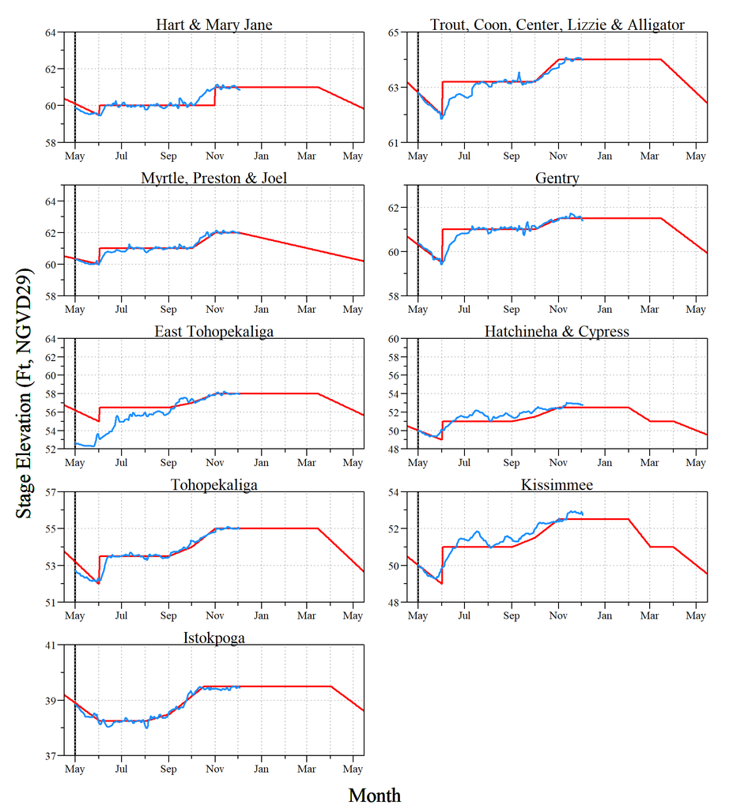

Kissimmee Chain-of-Lakes relative to each respective regulation schedule.

Data are provisional and subject to change.

### *Lake Okeechobee*

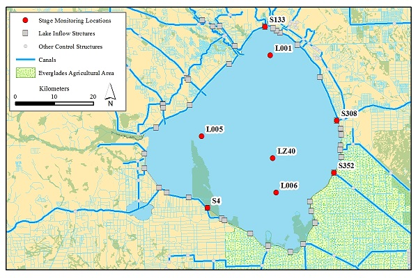

Lake Okeechobee with stage monitoring points and inflow structures identified.

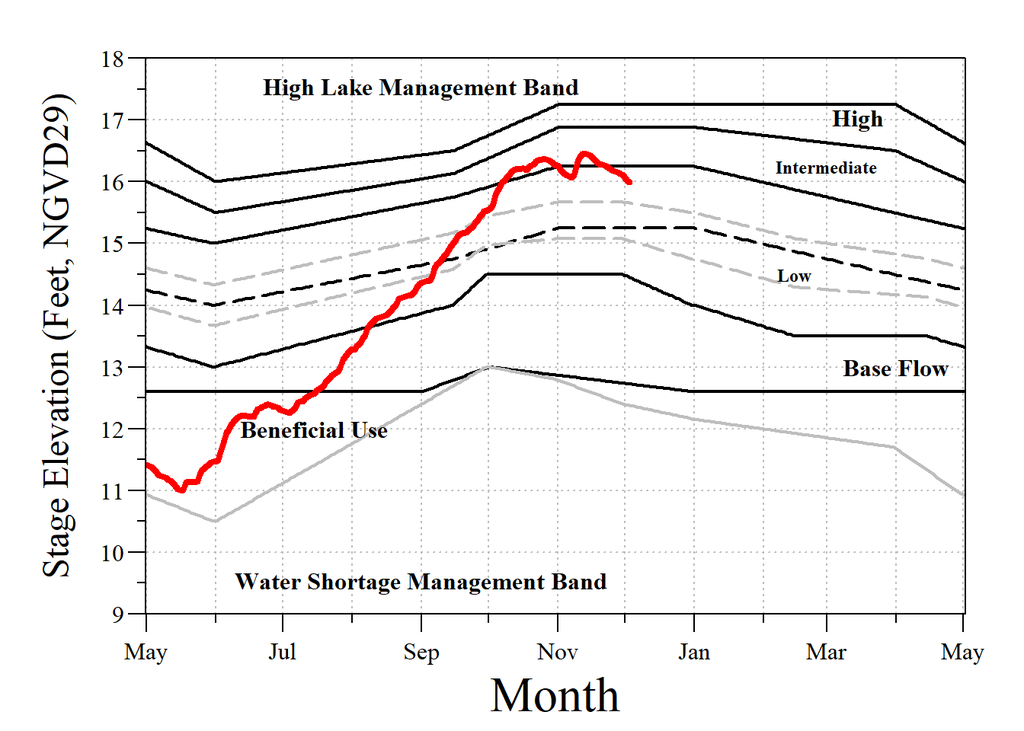

Lake Okeechobee daily average stage elevation (red line) relative to the Lake Okeechobee Regulation Schedule (LORS). Mean stage is calculated using data from L001, L005, L006, LZ40, S4TW,S352HW, S308HW & S133TW.

Data are provisional and subject to change.

### *Rotenberger and Holey Land Wildlife Management Areas*

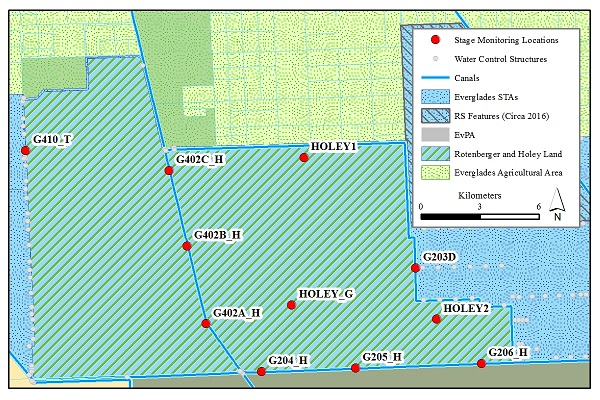

Rotenberger and Holey Land Wildlife Management Areas with stage monitoring points and inflow structures identified.(STAs=Stormwater Treatment Areas; RS= Restoration Strategies; EvPA=Everglades Protection Area)

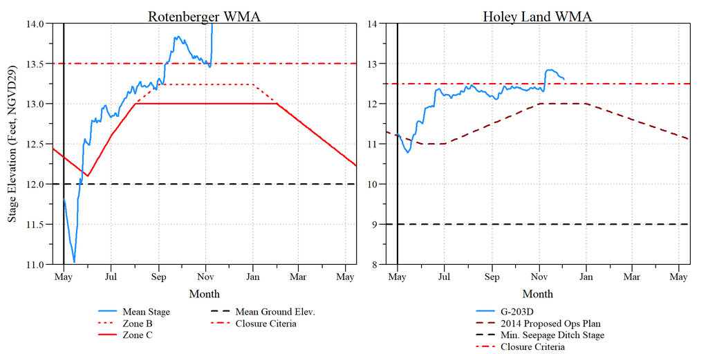

Mean stage elevation for Rotenberger (RotenN and RotenS) and Holey Land (G-203D) Wildlife Management Areas relative to water management schedules.Note the regulation schedule for Holey Land WMA is a proposed water management schedule and has not been reviewed or approved by FDEP.

Data are provisional and subject to change.

### *Water Conservation Area 1*

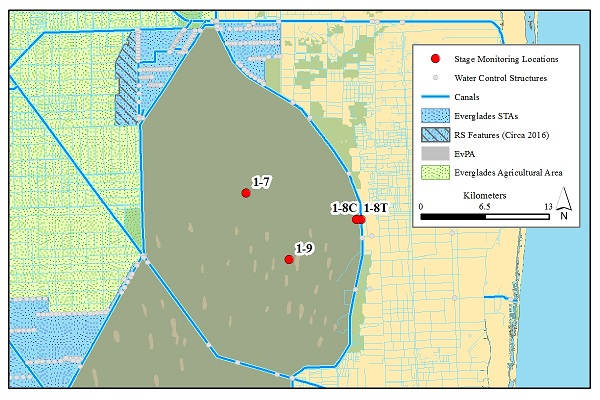

Water Conservation Area-1 with stage monitoring points and water control structures identified.(STAs=Stormwater Treatment Areas; RS= Restoration Strategies; EvPA=Everglades Protection Area)

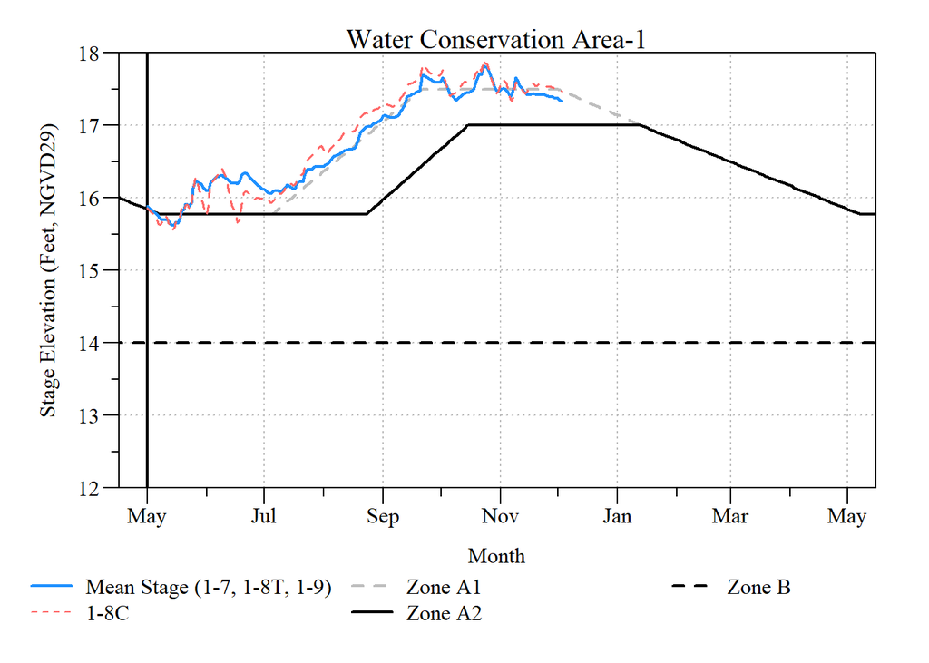

Mean stage elevation for Water Conservation Area-1 relative to water management schedules.

Data are provisional and subject to change.

### *Water Conservation Area 2*

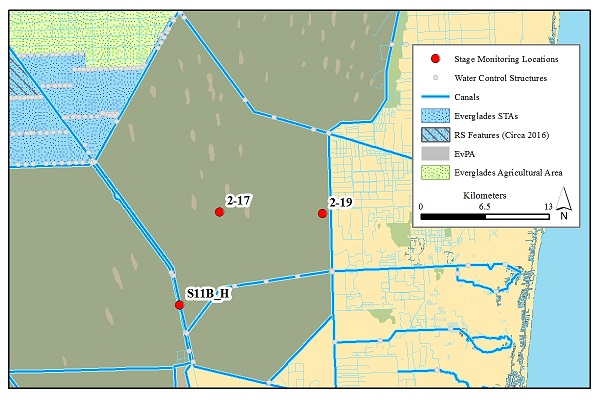

Water Conservation Area-2 with stage monitoring points and water control structures identified.(STAs=Stormwater Treatment Areas; RS= Restoration Strategies; EvPA=Everglades Protection Area)

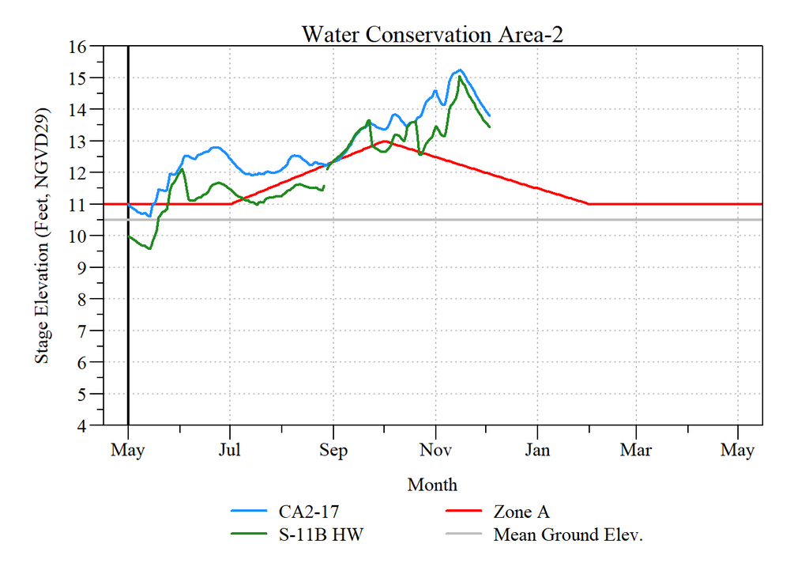

Mean stage elevation for Water Conservation Area-2 relative to water management schedules.

Data are provisional and subject to change.

### *Water Conservation Area 3*

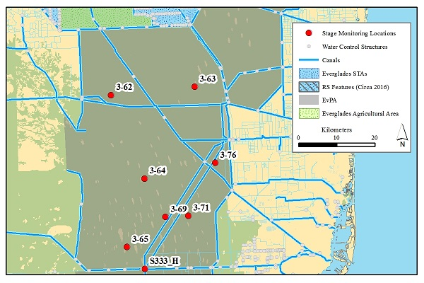

Water Conservation Area-3 with stage monitoring points and water control structures identified.(STAs=Stormwater Treatment Areas; RS= Restoration Strategies; EvPA=Everglades Protection Area)

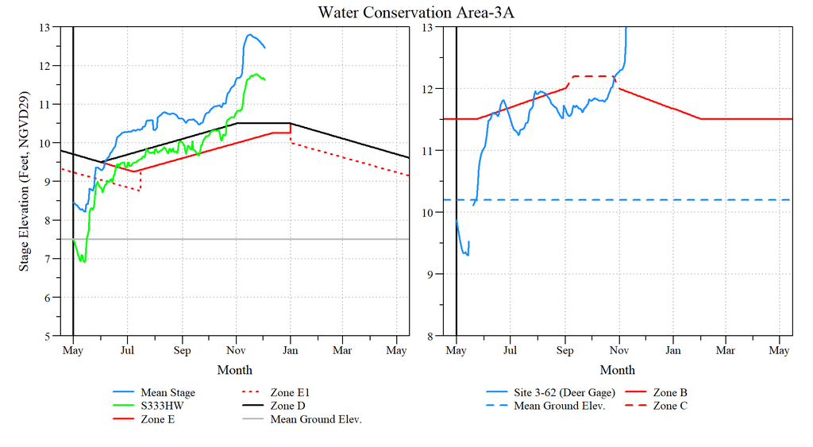

WCA3A mean stage (Sites 3-63,3-64 and 3-65), S333 Headwater, Site 3-62 stage elevation for Water Conservation Area-3A relative to water management schedules.

Data are provisional and subject to change.

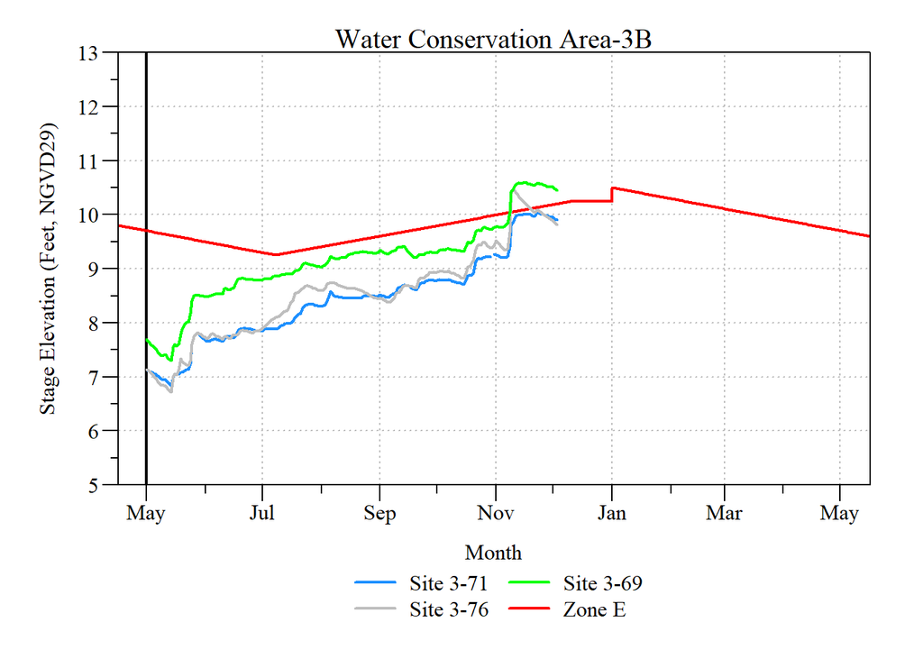

Mean stage elevation for Water Conservation Area-3B (WCA-3B) relative to WCA-3A, Zone E water management schedule.

Data are provisional and subject to change.

### *Everglades National Park*

#### Shark River Slough

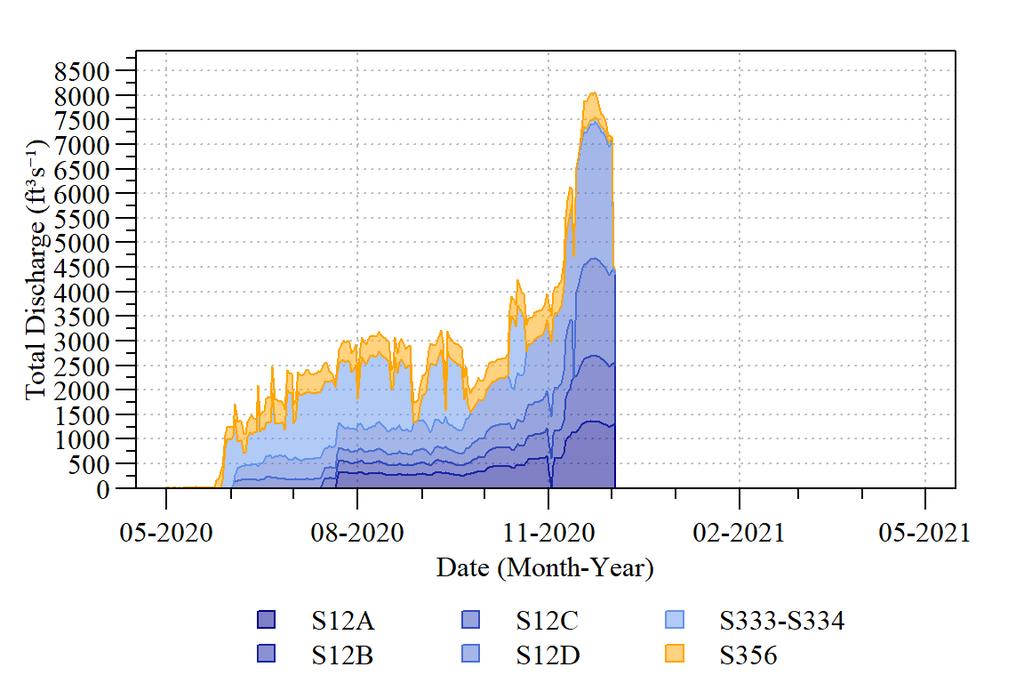

Daily total discharge into Shark River Slough.

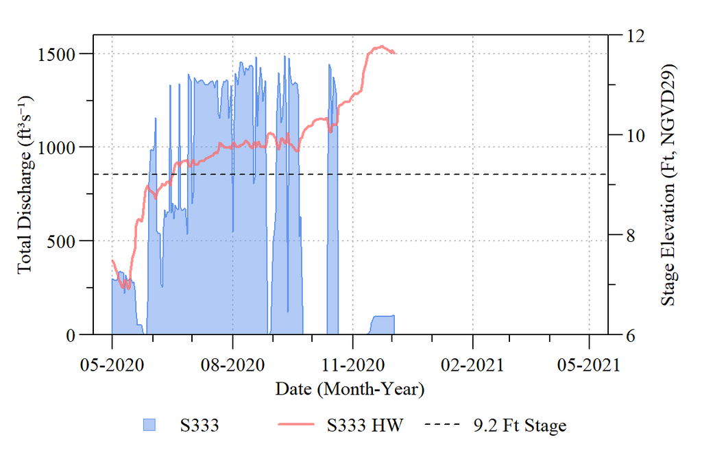

Daily total discharge and headwater stage at S333.

S333 daily maximum gate opening for Dec 03, 2020 was 0.33 Feet.

#### L-29 Canal

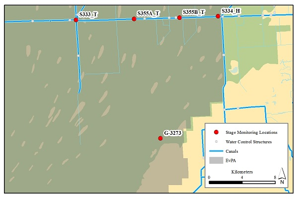

Stage monitoring locations along the L-29 Canal, north of Everglades National and south of Water Conservation Area-3B.

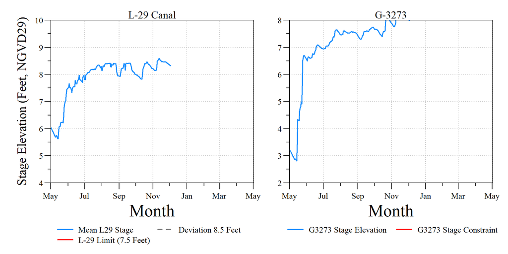

Daily mean stage elevation for L-29 (S333 TW and S334 HW) and G-3273 relative to each respective limits.

Data are provisional and subject to change.

L-29 and G3273 summary statistics for the period presented above..

```
##    Area Min  Q1 Median Mean  Q3 Max
##    L-29 5.6 7.8    8.2  7.9 8.4 8.6
##  G-3273 2.8 7.0    7.5  7.1 7.7 8.3
```

#### Cape Sable Seaside Sparrow

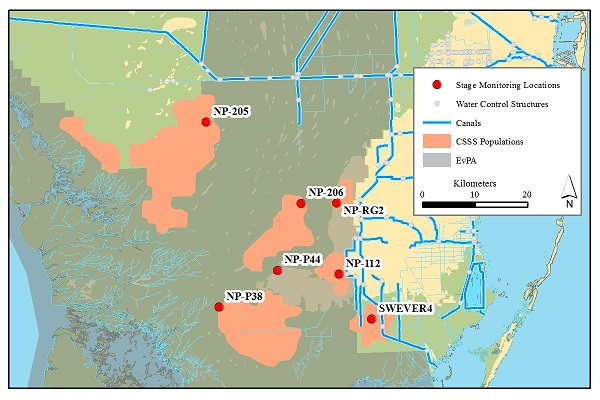

Stage monitoring locations within Everglades National Park relative to Cape Sable Seaside Sparrow populations. (EvPA=Everglades Protection Area; CSSS=Cape Sable Seaside Sparrow).

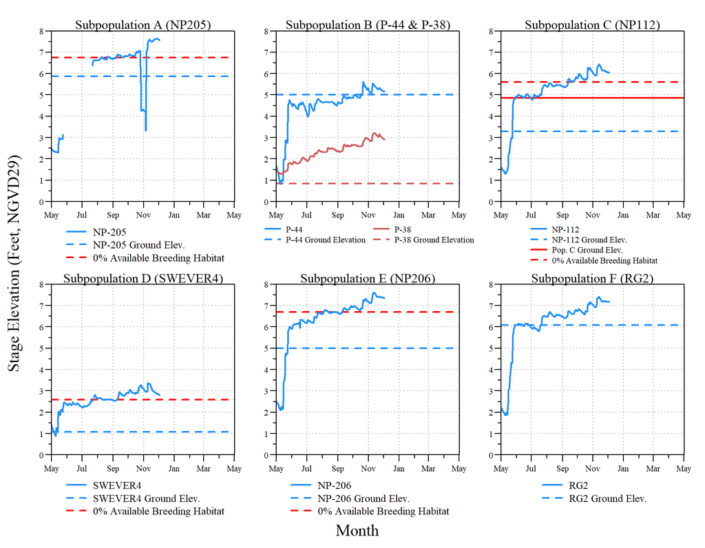

Daily mean stage elevation for each CSSS subpopulation relative to ground elevation (when available) and 0% available breeding population (when available).

Data are provisional and subject to change.

[figure not shown]

Office of Water Policy and Ecosystems Restoration